# Week 7: Building a ML End-to-End Project

# Decision Trees

Decision trees consist of a series of split points, often referred to as nodes. In order to make a prediction using a decision tree, we start at the top of the tree at a single node known as the root node. The root node is a decision or split point, because it places a condition in terms of the value of one of the input features, and based on this decision we know whether to continue on with the left part of the tree or with the right part of the tree. We repeat this process of choosing to go left or right at each inner node that we encounter until we reach one of the leaf nodes. These are the nodes at the base of the tree, which give us a specific value of the output to use as our prediction.

```r
# Create a vector with the 70% of the dataset with respect to diagnosis variable

set.seed(1)

inTrain = createDataPartition(med$diagnosis, p = .7)[[1]]

# Assign the 70% of observations to training data

training <- med[inTrain,]

# Assign the remaining 30 % of observations to testing data

testing <- med[-inTrain,]

# Set seed (in order all results to be fully reproducible) and apply a prediction

#Model with all variables

set.seed(2)

model.all <- train(diagnosis ~ ., method="rpart", data = training)

# Apply the prediction

prediction <- predict(model.all, newdata= testing)

#Check the accuracy of the prediction model by printing the confusion matrix

print(confusionMatrix(prediction, testing$diagnosis), digits=4)
```

```
Confusion Matrix and Statistics

          Reference
Prediction  B  M
         B 97  4
         M 10 59

               Accuracy : 0.9176
                 95% CI : (0.8657, 0.9542)
    No Information Rate : 0.6294
    P-Value [Acc > NIR] : <0.0000000000000002

                  Kappa : 0.8269

 Mcnemar's Test P-Value : 0.1814

            Sensitivity : 0.9065
            Specificity : 0.9365
         Pos Pred Value : 0.9604
         Neg Pred Value : 0.8551
             Prevalence : 0.6294
         Detection Rate : 0.5706
   Detection Prevalence : 0.5941
      Balanced Accuracy : 0.9215

       'Positive' Class : B
```

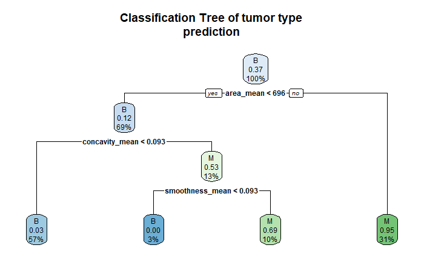

```r
library(rpart.plot)
# Plot the Classification Tree
rpart.plot(model.all$finalModel, main = "Classification Tree of tumor type
prediction")
```

# Results